# GAM PAM

Jessica Glazner

2024-11-22

# Project overview

### The goal of the NASTE project was to test how different sources of enrichment influence corals with and without thermal stress. We used four differnt enrichment sources, seabird guano, wastewater effluent, inorganic nutrients, and a control seawater, in this 83 day long experiment. Two species of coral, Montipora capitata and Porites compressa, were used, and half of the corals were also run through a simulated bleaching event (MMM +3 C) from days 40-54 (Mcap) and 40-55 (Pcom). The photochemical efficiency (FvFm) of each coral fragment was measured weekly to determine how the different enrichment and heat treatments were affecting photosynthesis.

```r
# load libraries
library(tidyverse)
library(lme4)
library(lmerTest)
library(emmeans)
library(car)
library(magrittr)
library(gamm4)
library(mgcv)
library(tidygam)
library(tidymv)
library(gridExtra)
#read in data

PAM <- read.csv("C:\\Users\\jglaz\\Desktop\\Datasets\\PAM_formatted.csv")

# subset dataframe by species

mc_pam <- PAM [PAM$species == "m",]
pc_pam <- PAM [PAM$species == "p",]

# create interaction term

pc_pam <- pc_pam %>% #create interaction term
  mutate(trt_temp = interaction(treatment, temp, drop=TRUE))

mc_pam <- mc_pam %>% #create interaction term
  mutate(trt_temp = interaction(treatment, temp, drop=TRUE))
```

```r
# Define colors for the treatments
naste_colors <- c("Control" = "#08b5d3",
               "Effluent" = "#e12618",
               "Guano" = "#01ad74",
               "Inorganic" = "#d9a33a")
```

```r
#mgvc package won't read character terms, must convert to factors
mc_pam$treatment<-as.factor(mc_pam$treatment)
mc_pam$temp<-as.factor(mc_pam$temp)
mc_pam$day<-as.numeric(mc_pam$day)
mc_pam$ID<-as.factor(mc_pam$ID)
mc_pam$genotype<-as.factor(mc_pam$genotype)
pc_pam$treatment<-as.factor(pc_pam$treatment)
pc_pam$temp<-as.factor(pc_pam$temp)
pc_pam$day<-as.numeric(pc_pam$day)
pc_pam$ID<-as.factor(pc_pam$ID)
pc_pam$genotype<-as.factor(pc_pam$genotype)
```

# Exploratory Plots and Analysis

```r
# Are there significant differences that can be explained by genotype?

  ## try lm with genotype as fixed effect
pc_geno <-lm(FvFm ~ genotype, data=pc_pam)
summary(pc_geno)
```

```
##
## Call:
## lm(formula = FvFm ~ genotype, data = pc_pam)
##
## Residuals:
##      Min       1Q   Median       3Q      Max
## -0.23186 -0.02575  0.01966  0.04029  0.08924
##
## Coefficients:
##               Estimate Std. Error t value Pr(>|t|)
## (Intercept)  0.4796456  0.0065214  73.549  < 2e-16 ***
## genotype2   -0.0093081  0.0091938  -1.012 0.311685
## genotype3   -0.0388824  0.0093132  -4.175 3.36e-05 ***
## genotype4   -0.0003831  0.0091938  -0.042 0.966777
## genotype5    0.0008801  0.0092522   0.095 0.924247
## genotype6   -0.0343122  0.0092522  -3.709 0.000225 ***
## genotype7    0.0040596  0.0092522   0.439 0.660966
## genotype8   -0.0072956  0.0091938  -0.794 0.427739
## genotype9   -0.0287884  0.0092824  -3.101 0.002004 **
## ---
## Signif. codes:  0 '***' 0.001 '**' 0.01 '*' 0.05 '.' 0.1 ' ' 1
##
## Residual standard error: 0.05796 on 697 degrees of freedom
## Multiple R-squared:  0.06874,    Adjusted R-squared:  0.05805
## F-statistic: 6.431 on 8 and 697 DF,  p-value: 4.363e-08
```

```r
mc_geno <-lm(FvFm ~ genotype, data=mc_pam)
summary(mc_geno)
```

```
##
## Call:
## lm(formula = FvFm ~ genotype, data = mc_pam)
##
## Residuals:
##      Min       1Q   Median       3Q      Max
## -0.37920 -0.01516  0.01077  0.03242  0.13180
##
## Coefficients:
##               Estimate Std. Error t value Pr(>|t|)
## (Intercept)  4.929e-01  7.189e-03  68.567  < 2e-16 ***
## genotype2    1.168e-02  1.017e-02   1.149  0.25088
## genotype3   -1.490e-02  1.017e-02  -1.465  0.14326
## genotype4   -7.374e-03  1.014e-02  -0.728  0.46711
## genotype5    2.410e-02  1.017e-02   2.371  0.01803 *
## genotype6   -2.795e-02  1.030e-02  -2.713  0.00683 **
## genotype7   -6.674e-02  1.045e-02  -6.387  3.1e-10 ***
## genotype8    1.133e-02  1.014e-02   1.117  0.26418
## genotype9    8.829e-05  1.014e-02   0.009  0.99305
## ---
## Signif. codes:  0 '***' 0.001 '**' 0.01 '*' 0.05 '.' 0.1 ' ' 1
##
## Residual standard error: 0.0639 on 693 degrees of freedom
## Multiple R-squared:  0.1319, Adjusted R-squared:  0.1219
## F-statistic: 13.16 on 8 and 693 DF,  p-value: < 2.2e-16
```

```r
  # yes, genotype is responsible for differences in FvFm values

  ## If we use genotype as a random effect in the lme

pc_lme <- lmer(FvFm ~ treatment * temp + (1|genotype), data=pc_pam)
summary(pc_lme)
```

```
## Linear mixed model fit by REML. t-tests use Satterthwaite's method [
## lmerModLmerTest]
## Formula: FvFm ~ treatment * temp + (1 | genotype)
##    Data: pc_pam
##
## REML criterion at convergence: -2117.1
##
## Scaled residuals:
##     Min      1Q  Median      3Q     Max
## -3.8336 -0.5467  0.0792  0.6167  2.1485
##
## Random effects:
##  Groups   Name        Variance  Std.Dev.
##  genotype (Intercept) 0.0002541 0.01594
##  Residual             0.0026135 0.05112
## Number of obs: 706, groups:  genotype, 9
##
## Fixed effects:
##                                 Estimate Std. Error         df t value Pr(>|t|)
## (Intercept)                     0.484256   0.007568  25.472359  63.991  < 2e-16
## treatmenteffluent               0.015789   0.007621 689.977283   2.072   0.0387
## treatmentguano                  0.016822   0.007621 689.977283   2.207   0.0276
## treatmentinorganic              0.001544   0.007621 689.977283   0.203   0.8395
## tempHeated                     -0.048769   0.007642 689.988071  -6.381 3.22e-10
## treatmenteffluent:tempHeated   -0.008812   0.010839 689.986568  -0.813   0.4165
## treatmentguano:tempHeated       0.001464   0.010924 690.014340   0.134   0.8935
## treatmentinorganic:tempHeated  -0.007176   0.010824 690.007046  -0.663   0.5076
##
## (Intercept)                   ***
## treatmenteffluent             *
## treatmentguano                *
## treatmentinorganic
## tempHeated                    ***
## treatmenteffluent:tempHeated
## treatmentguano:tempHeated
## treatmentinorganic:tempHeated
## ---
## Signif. codes:  0 '***' 0.001 '**' 0.01 '*' 0.05 '.' 0.1 ' ' 1
##
## Correlation of Fixed Effects:
##             (Intr) trtmntf trtmntg trtmntn tmpHtd trtmntf:H trtmntg:H
## trtmntfflnt -0.504
## treatmentgn -0.504  0.500
## trtmntnrgnc -0.504  0.500   0.500
## tempHeated  -0.502  0.499   0.499   0.499
## trtmntffl:H  0.354 -0.703  -0.352  -0.352  -0.705
## trtmntgn:tH  0.351 -0.349  -0.698  -0.349  -0.700  0.493
## trtmntnrg:H  0.355 -0.352  -0.352  -0.704  -0.706  0.498     0.494
```

```r
  # 8.9% of variation in pcom FvFm is due to genotype (in random effect section of output: genotype/(geonotype+residual)

mc_lme <- lmer(FvFm ~ treatment * temp + (1|genotype), data=mc_pam)
summary(mc_lme)
```

```
## Linear mixed model fit by REML. t-tests use Satterthwaite's method [
## lmerModLmerTest]
## Formula: FvFm ~ treatment * temp + (1 | genotype)
##    Data: mc_pam
##
## REML criterion at convergence: -1880.8
##
## Scaled residuals:
##     Min      1Q  Median      3Q     Max
## -5.8946 -0.3096  0.0759  0.5540  2.2755
##
## Random effects:
##  Groups   Name        Variance  Std.Dev.
##  genotype (Intercept) 0.0007052 0.02656
##  Residual             0.0035823 0.05985
## Number of obs: 702, groups:  genotype, 9
##
## Fixed effects:
##                                 Estimate Std. Error         df t value Pr(>|t|)
## (Intercept)                     0.499922   0.010870  15.888962  45.990  < 2e-16
## treatmenteffluent               0.006678   0.008922 685.944028   0.748   0.4545
## treatmentguano                  0.016244   0.008922 685.944027   1.821   0.0691
## treatmentinorganic              0.001078   0.008922 685.944028   0.121   0.9039
## tempHeated                     -0.049274   0.009001 685.998122  -5.474 6.18e-08
## treatmenteffluent:tempHeated    0.019702   0.012879 686.119397   1.530   0.1265
## treatmentguano:tempHeated       0.004613   0.012746 685.962185   0.362   0.7176
## treatmentinorganic:tempHeated   0.004161   0.012692 685.977105   0.328   0.7431
##
## (Intercept)                   ***
## treatmenteffluent
## treatmentguano                .
## treatmentinorganic
## tempHeated                    ***
## treatmenteffluent:tempHeated
## treatmentguano:tempHeated
## treatmentinorganic:tempHeated
## ---
## Signif. codes:  0 '***' 0.001 '**' 0.01 '*' 0.05 '.' 0.1 ' ' 1
##
## Correlation of Fixed Effects:
##             (Intr) trtmntf trtmntg trtmntn tmpHtd trtmntf:H trtmntg:H
## trtmntfflnt -0.410
## treatmentgn -0.410  0.500
## trtmntnrgnc -0.410  0.500   0.500
## tempHeated  -0.407  0.496   0.496   0.496
## trtmntffl:H  0.284 -0.693  -0.346  -0.346  -0.699
## trtmntgn:tH  0.287 -0.350  -0.700  -0.350  -0.706  0.494
## trtmntnrg:H  0.289 -0.351  -0.351  -0.703  -0.709  0.496     0.501
```

```r
  # 16.4% of variation in mcap FvFm is due to genotype

# Genotype did explain some varation in the different FvFm scores (particularly in Mcap), however because it was a small amount of variation explained by genotype differences, we are not going to include genotype as a random effect in the GAM (for now)
```

# GAMS

### Utilizing a gam model structure to capture the non-linear response of FvFm to the different treatments.

## PORITES

```r
# Write different model options
  # Model 1 -different slope and different intercept
  # Model 2 - same slope and different intercept
  # Model 3 - global smoother assuming no treatment differences by day

# Note-allowing 'k' to be set automatically by the model, we can adjust to increase or decrease the 'wiggliness'

pc_pam_1 <- gam(FvFm~ trt_temp + s(day,by=trt_temp),data=pc_pam) #interaction term smoothed by day
summary(pc_pam_1)
```

```
##
## Family: gaussian
## Link function: identity
##
## Formula:
## FvFm ~ trt_temp + s(day, by = trt_temp)
##
## Parametric coefficients:
##                            Estimate Std. Error t value Pr(>|t|)
## (Intercept)                0.484470   0.003087 156.924  < 2e-16 ***
## trt_tempeffluent.Ambient   0.015686   0.004366   3.593 0.000352 ***
## trt_tempguano.Ambient      0.016784   0.004366   3.844 0.000133 ***
## trt_tempinorganic.Ambient  0.001452   0.004366   0.333 0.739493
## trt_tempcontrol.Heated    -0.048497   0.004377 -11.081  < 2e-16 ***
## trt_tempeffluent.Heated   -0.042035   0.004407  -9.538  < 2e-16 ***
## trt_tempguano.Heated      -0.030784   0.004520  -6.811 2.22e-11 ***
## trt_tempinorganic.Heated  -0.055023   0.004390 -12.533  < 2e-16 ***
## ---
## Signif. codes:  0 '***' 0.001 '**' 0.01 '*' 0.05 '.' 0.1 ' ' 1
##
## Approximate significance of smooth terms:
##                                    edf Ref.df      F  p-value
## s(day):trt_tempcontrol.Ambient   7.503  8.449  3.808 0.000177 ***
## s(day):trt_tempeffluent.Ambient  3.600  4.435  3.306 0.008538 **
## s(day):trt_tempguano.Ambient     4.774  5.820  4.424 0.000244 ***
## s(day):trt_tempinorganic.Ambient 5.413  6.536  4.685 9.31e-05 ***
## s(day):trt_tempcontrol.Heated    6.640  7.766 49.364  < 2e-16 ***
## s(day):trt_tempeffluent.Heated   7.343  8.342 46.305  < 2e-16 ***
## s(day):trt_tempguano.Heated      7.324  8.330 32.701  < 2e-16 ***
## s(day):trt_tempinorganic.Heated  8.314  8.873 55.318  < 2e-16 ***
## ---
## Signif. codes:  0 '***' 0.001 '**' 0.01 '*' 0.05 '.' 0.1 ' ' 1
##
## R-sq.(adj) =   0.76   Deviance explained =   78%
## GCV = 0.00093425  Scale est. = 0.00085629  n = 706
```

```r
anova.gam(pc_pam_1)
```

```
##
## Family: gaussian
## Link function: identity
##
## Formula:
## FvFm ~ trt_temp + s(day, by = trt_temp)
##
## Parametric Terms:
##          df     F p-value
## trt_temp  7 90.02  <2e-16
##
## Approximate significance of smooth terms:
##                                    edf Ref.df      F  p-value
## s(day):trt_tempcontrol.Ambient   7.503  8.449  3.808 0.000177
## s(day):trt_tempeffluent.Ambient  3.600  4.435  3.306 0.008538
## s(day):trt_tempguano.Ambient     4.774  5.820  4.424 0.000244
## s(day):trt_tempinorganic.Ambient 5.413  6.536  4.685 9.31e-05
## s(day):trt_tempcontrol.Heated    6.640  7.766 49.364  < 2e-16
## s(day):trt_tempeffluent.Heated   7.343  8.342 46.305  < 2e-16
## s(day):trt_tempguano.Heated      7.324  8.330 32.701  < 2e-16
## s(day):trt_tempinorganic.Heated  8.314  8.873 55.318  < 2e-16
```

```r
pc_pam_2 <- gam(FvFm~ trt_temp + s(day), data=pc_pam) #interaction term and smoothed day
summary(pc_pam_2)
```

```
##
## Family: gaussian
## Link function: identity
##
## Formula:
## FvFm ~ trt_temp + s(day)
##
## Parametric coefficients:
##                            Estimate Std. Error t value Pr(>|t|)
## (Intercept)                0.484512   0.003970 122.058  < 2e-16 ***
## trt_tempeffluent.Ambient   0.015789   0.005613   2.813  0.00505 **
## trt_tempguano.Ambient      0.016822   0.005613   2.997  0.00282 **
## trt_tempinorganic.Ambient  0.001544   0.005613   0.275  0.78328
## trt_tempcontrol.Heated    -0.048618   0.005629  -8.637  < 2e-16 ***
## trt_tempeffluent.Heated   -0.042172   0.005663  -7.447 2.86e-13 ***
## trt_tempguano.Heated      -0.030644   0.005756  -5.324 1.38e-07 ***
## trt_tempinorganic.Heated  -0.054806   0.005645  -9.709  < 2e-16 ***
## ---
## Signif. codes:  0 '***' 0.001 '**' 0.01 '*' 0.05 '.' 0.1 ' ' 1
##
## Approximate significance of smooth terms:
##          edf Ref.df    F p-value
## s(day) 7.238  8.261 84.7  <2e-16 ***
## ---
## Signif. codes:  0 '***' 0.001 '**' 0.01 '*' 0.05 '.' 0.1 ' ' 1
##
## R-sq.(adj) =  0.603   Deviance explained = 61.1%
## GCV = 0.0014491  Scale est. = 0.0014178  n = 706
```

```r
anova.gam(pc_pam_2)
```

```
##
## Family: gaussian
## Link function: identity
##
## Formula:
## FvFm ~ trt_temp + s(day)
##
## Parametric Terms:
##          df     F p-value
## trt_temp  7 54.52  <2e-16
##
## Approximate significance of smooth terms:
##          edf Ref.df    F p-value
## s(day) 7.238  8.261 84.7  <2e-16
```

```r
pc_pam_3 <- gam(FvFm~ s(day), data=pc_pam) #interaction term and smoothed day
summary(pc_pam_3)
```

```
##
## Family: gaussian
## Link function: identity
##
## Formula:
## FvFm ~ s(day)
##
## Parametric coefficients:
##             Estimate Std. Error t value Pr(>|t|)
## (Intercept) 0.467150   0.001757   265.8   <2e-16 ***
## ---
## Signif. codes:  0 '***' 0.001 '**' 0.01 '*' 0.05 '.' 0.1 ' ' 1
##
## Approximate significance of smooth terms:
##          edf Ref.df     F p-value
## s(day) 6.723   7.84 57.19  <2e-16 ***
## ---
## Signif. codes:  0 '***' 0.001 '**' 0.01 '*' 0.05 '.' 0.1 ' ' 1
##
## R-sq.(adj) =  0.389   Deviance explained = 39.4%
## GCV = 0.0022048  Scale est. = 0.0021807  n = 706
```

```r
anova.gam(pc_pam_3)
```

```
##
## Family: gaussian
## Link function: identity
##
## Formula:
## FvFm ~ s(day)
##
## Approximate significance of smooth terms:
##          edf Ref.df     F p-value
## s(day) 6.723  7.840 57.19  <2e-16
```

```r
# compare models
pc_AIC <- AIC (pc_pam_1, pc_pam_2, pc_pam_3)
print(pc_AIC) # best option is pc_pam_1 (smallest AIC score) with the interaction term smoothed by day
```

```
##                 df       AIC
## pc_pam_1 59.912292 -2924.559
## pc_pam_2 16.237957 -2609.802
## pc_pam_3  8.723434 -2313.232
```

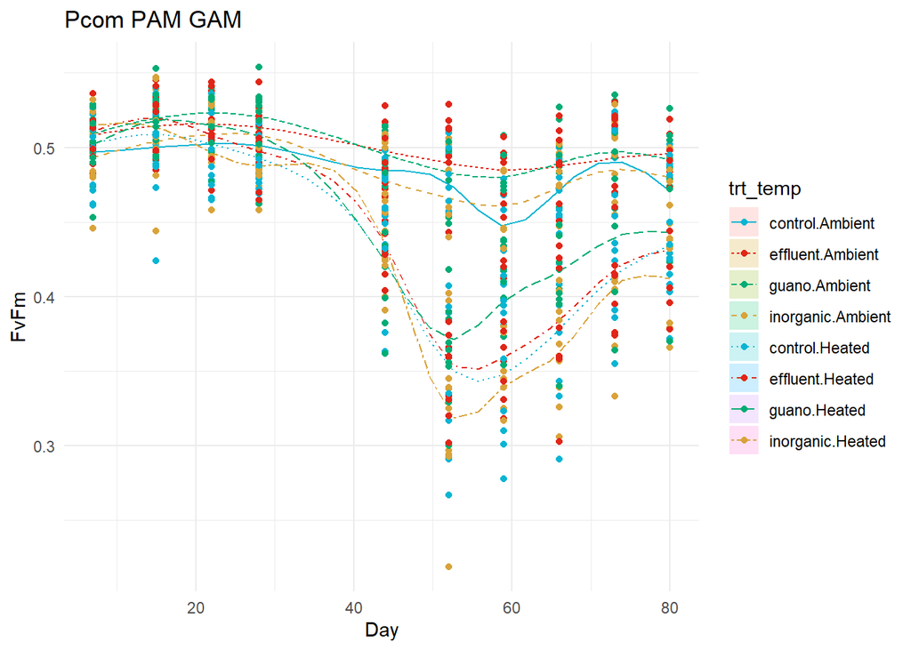

```r
# Plot_smooths for the model output on rawdata - needs a few formatting adjustments
pc_pam_plot<-
  plot_smooths(
  model = pc_pam_1,
series = day,
comparison= trt_temp,
ci_z = 0) +
  geom_point(data=pc_pam,
             aes(x=day, y=FvFm, color=trt_temp)) +
  scale_color_manual(values = c("#08b5d3","#e12618","#01ad74","#d9a33a","#08b5d3","#e12618","#01ad74","#d9a33a")) +
  ggtitle("Pcom PAM GAM") +
  ylab("FvFm") +
  xlab("Day") +
  theme_minimal()
pc_pam_plot
```

## Plot_differences

### Compare each treatment to their heated counterpart

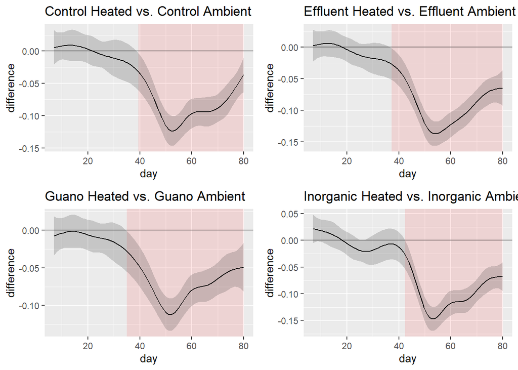

```r
# Define a list of your comparisons
comparisons <- list(
  list(name = "ch_ca", difference = c("control.Heated", "control.Ambient"), title = "Control Heated vs. Control Ambient"),
  list(name = "eh_ea", difference = c("effluent.Heated", "effluent.Ambient"), title = "Effluent Heated vs. Effluent Ambient"),
  list(name = "gh_ga", difference = c("guano.Heated", "guano.Ambient"), title = "Guano Heated vs. Guano Ambient"),
  list(name = "ih_ia", difference = c("inorganic.Heated", "inorganic.Ambient"), title = "Inorganic Heated vs. Inorganic Ambient")
)

# Loop through each comparison to generate plots
plots <- list()  # Initialize an empty list to store plots

for (comp in comparisons) {
  plot <- plot_difference(
    pc_pam_1,
    series = day,
    difference = list(trt_temp = comp$difference)
  ) + ggtitle(comp$title)
    plots[[comp$name]] <- plot
}

# Display plots
grid.arrange(
  plots$ch_ca,
  plots$eh_ea,
  plots$gh_ga,
  plots$ih_ia,
  ncol = 2
)
```

#### Heat was introduced on day 40, we can see that all treatments divereged around day 40. Max FvFm value in dataset was 0.554 and min was 0.219, total range of 0.335. The introduction of heat approximately decreased FvFm values by 37.3% in control corals, 38.8% in effluent corals, 32.8% in guano corals, and 44.8% in inorganic corals. Percentages found by looking at each max difference/0.335. Eg for control 0.125/0.335=0.373

## Difference in all ambient corals to see if treatment had an effect on FvFm

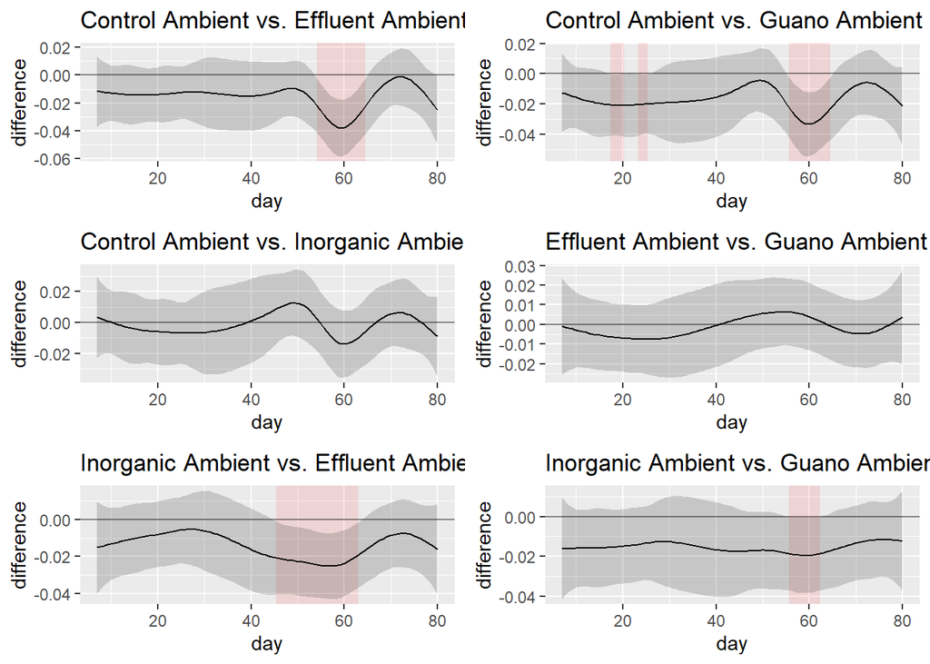

```r
# Define a list of the new comparisons
amb_comparisons <- list(
  list(name = "ca_ea", difference = c("control.Ambient", "effluent.Ambient"), title = "Control Ambient vs. Effluent Ambient"),
  list(name = "ca_ga", difference = c("control.Ambient", "guano.Ambient"), title = "Control Ambient vs. Guano Ambient"),
  list(name = "ca_ia", difference = c("control.Ambient", "inorganic.Ambient"), title = "Control Ambient vs. Inorganic Ambient"),
  list(name = "ea_ga", difference = c("effluent.Ambient", "guano.Ambient"), title = "Effluent Ambient vs. Guano Ambient"),
  list(name = "ia_ea", difference = c("inorganic.Ambient", "effluent.Ambient"), title = "Inorganic Ambient vs. Effluent Ambient"),
  list(name = "ia_ga", difference = c("inorganic.Ambient", "guano.Ambient"), title = "Inorganic Ambient vs. Guano Ambient")
)

# Initialize an empty list to store the new plots
amb_plots <- list()

# Loop through each new comparison to generate plots
for (comp in amb_comparisons) {
  plot <- plot_difference(
    pc_pam_1,
    series = day,
    difference = list(trt_temp = comp$difference)
  ) + ggtitle(comp$title)
    amb_plots[[comp$name]] <- plot
}


# Display plots
grid.arrange(
  amb_plots$ca_ea,
  amb_plots$ca_ga,
  amb_plots$ca_ia,
  amb_plots$ea_ga,
  amb_plots$ia_ea,
  amb_plots$ia_ga,
  ncol = 2
)
```

#### There are differenecs between treatments. The max ambient FvFm value is 0.554 and min is 0.376, the range of values is 0.178. Control is approx. 22.5% lower than effluent and 19.7% lower than guano between days 55-65. Inorganic is 14% lower than effluent (days 45-62) and 11.2% lower than guano (days 55-62). Control and inorganic the same. Effluent and guano the same. *NOTE - ambient temps reached 28 C around day 50 for a few days, potentally why we see divergence in treatment effects at that time.

## Difference in all heated corals to see if treatment x heat had an effect on FvFm

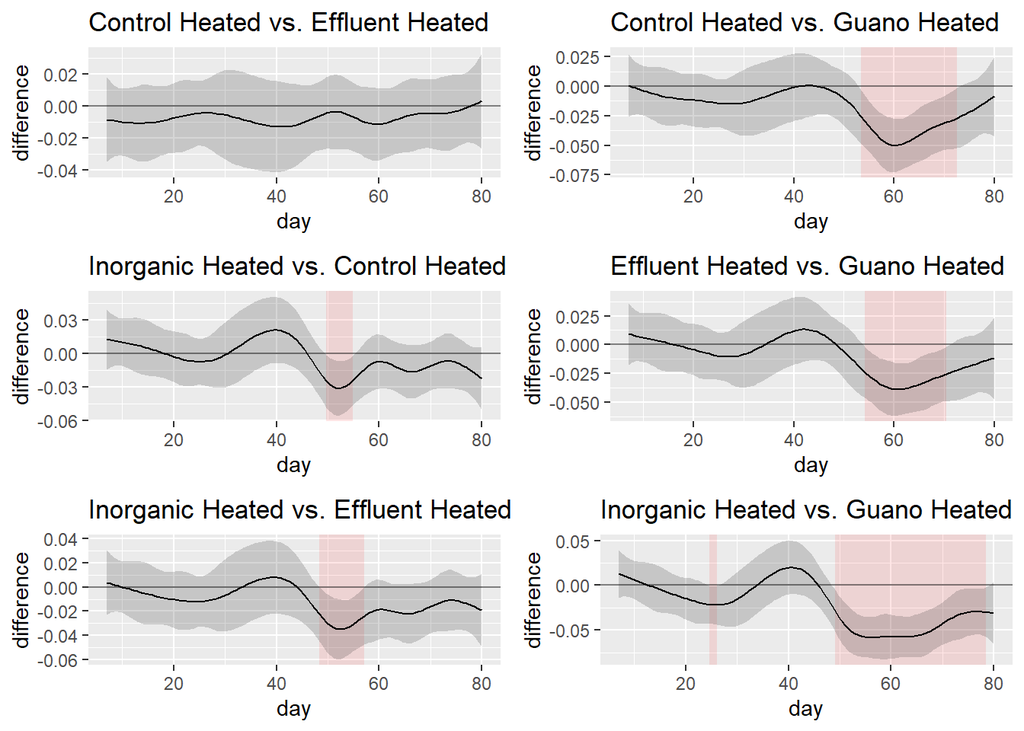

```r
# Define a list of the new comparisons
heat_comparisons <- list(
  list(name = "ch_eh", difference = c("control.Heated", "effluent.Heated"), title = "Control Heated vs. Effluent Heated"),
  list(name = "ch_gh", difference = c("control.Heated", "guano.Heated"), title = "Control Heated vs. Guano Heated"),
  list(name = "ih_ch", difference = c("inorganic.Heated", "control.Heated"), title = "Inorganic Heated vs. Control Heated"),
  list(name = "eh_gh", difference = c("effluent.Heated", "guano.Heated"), title = "Effluent Heated vs. Guano Heated"),
  list(name = "ih_eh", difference = c("inorganic.Heated", "effluent.Heated"), title = "Inorganic Heated vs. Effluent Heated"),
  list(name = "ih_gh", difference = c("inorganic.Heated", "guano.Heated"), title = "Inorganic Heated vs. Guano Heated")
)

# Initialize an empty list to store the new plots
heat_plots <- list()

# Loop through each new comparison to generate plots
for (comp in heat_comparisons) {
  plot <- plot_difference(
    pc_pam_1,
    series = day,
    difference = list(trt_temp = comp$difference)
  ) + ggtitle(comp$title)
    heat_plots[[comp$name]] <- plot
}


# Display plots
grid.arrange(
  heat_plots$ch_eh,
  heat_plots$ch_gh,
  heat_plots$ih_ch,
  heat_plots$eh_gh,
  heat_plots$ih_eh,
  heat_plots$ih_gh,
  ncol = 2
)
```

```r
# max heated value is 0.553 and min is 0.219, range is 0.334
```

#### Max heated FvFm value is 0.553 and min is 0.219, range is 0.334. Inorganic was approx. 9% lower than control, 12% lower than effluent, and 18% lower than guano during max heat (and through recovery for guano).Guano was 15% higher than control and 11.2% higher than effluent corals during max heat and early recovery. Control and effluent were similar.

#### Overall interpretation of Porites - heat significantly decreased FvFm values in all treatments, guano had the smallest difference (32.8%) and inorganic had the greatest difference (44.8%). With the addition of nutrient treatments to ambient corals, both effluent and guano supported higher FvFm values compared to control and inorganic treatments, but only between days 45-65 (ish). During the interaction of heat x treatment, guano corals performed significantly better than the other 3 treatments, while inorganic corals had significantly lower FvFm values than the other 3 treatments.

#### Significance: Guano supported photochemical efficiency in corals with and without heat. Effluent supported photochemical efficiency without heat, but when heat was introduced it performed no different than the control corals. The addition of just nutrients (inorganic) without the rest of the ‘stuff’ in each source had the greatest negative impact on the corals.

## Linear Mixed Effects Model on just heated corals from day 40 - 80 (start of heating to end of experiment)

```r
# filter dataset
pc_heat <- pc_pam [pc_pam$temp == "Heated",]
pc_heat <- pc_heat %>%
  filter(day >= 40)


#lme
pc_heat_lme <- lmer(FvFm ~ treatment + (1|genotype) + (1|ID), data=pc_heat)
summary(pc_heat_lme)
```

```
## Linear mixed model fit by REML. t-tests use Satterthwaite's method [
## lmerModLmerTest]
## Formula: FvFm ~ treatment + (1 | genotype) + (1 | ID)
##    Data: pc_heat
##
## REML criterion at convergence: -611.5
##
## Scaled residuals:
##     Min      1Q  Median      3Q     Max
## -2.9729 -0.7029  0.1101  0.7245  2.1036
##
## Random effects:
##  Groups   Name        Variance  Std.Dev.
##  ID       (Intercept) 0.0003262 0.01806
##  genotype (Intercept) 0.0003170 0.01780
##  Residual             0.0021412 0.04627
## Number of obs: 202, groups:  ID, 36; genotype, 9
##
## Fixed effects:
##                    Estimate Std. Error       df t value Pr(>|t|)
## (Intercept)         0.39081    0.01058 24.16138  36.939   <2e-16 ***
## treatmenteffluent   0.00484    0.01245 23.59633   0.389    0.701
## treatmentguano      0.01761    0.01266 25.01642   1.391    0.176
## treatmentinorganic -0.01192    0.01243 23.37248  -0.959    0.347
## ---
## Signif. codes:  0 '***' 0.001 '**' 0.01 '*' 0.05 '.' 0.1 ' ' 1
##
## Correlation of Fixed Effects:
##             (Intr) trtmntf trtmntg
## trtmntfflnt -0.582
## treatmentgn -0.573  0.487
## trtmntnrgnc -0.583  0.496   0.488
```

#### No significant differences between treatments during heating/recovery phase

## MONITPORA

```r
# Write different model options
  # Model 1 -different slope and different intercept
  # Model 2 - same slope and different intercept
  # Model 3 - global smoother assuming no treatment differences by day

# Note-allowing 'k' to be set automatically by the model, we can adjust to increase or decrease the 'wiggliness'

mc_pam_1 <- gam(FvFm~ trt_temp + s(day,by=trt_temp),data=mc_pam) #interaction term smoothed by day
summary(mc_pam_1)
```

```
##
## Family: gaussian
## Link function: identity
##
## Formula:
## FvFm ~ trt_temp + s(day, by = trt_temp)
##
## Parametric coefficients:
##                             Estimate Std. Error t value Pr(>|t|)
## (Intercept)                0.4999926  0.0061506  81.292  < 2e-16 ***
## trt_tempeffluent.Ambient   0.0065100  0.0086982   0.748  0.45446
## trt_tempguano.Ambient      0.0160581  0.0086982   1.846  0.06531 .
## trt_tempinorganic.Ambient  0.0009851  0.0086982   0.113  0.90986
## trt_tempcontrol.Heated    -0.0489064  0.0087744  -5.574 3.61e-08 ***
## trt_tempeffluent.Heated   -0.0217096  0.0089798  -2.418  0.01589 *
## trt_tempguano.Heated      -0.0260944  0.0088096  -2.962  0.00316 **
## trt_tempinorganic.Heated  -0.0428315  0.0087222  -4.911 1.14e-06 ***
## ---
## Signif. codes:  0 '***' 0.001 '**' 0.01 '*' 0.05 '.' 0.1 ' ' 1
##
## Approximate significance of smooth terms:
##                                    edf Ref.df      F  p-value
## s(day):trt_tempcontrol.Ambient   1.000  1.000  0.260    0.610
## s(day):trt_tempeffluent.Ambient  1.000  1.000  0.498    0.480
## s(day):trt_tempguano.Ambient     1.000  1.000  0.706    0.401
## s(day):trt_tempinorganic.Ambient 1.000  1.000  0.026    0.871
## s(day):trt_tempcontrol.Heated    6.012  7.163  6.359  < 2e-16 ***
## s(day):trt_tempeffluent.Heated   2.525  3.135  7.985 2.47e-05 ***
## s(day):trt_tempguano.Heated      5.897  7.048  5.791 1.43e-06 ***
## s(day):trt_tempinorganic.Heated  3.405  4.203 13.002  < 2e-16 ***
## ---
## Signif. codes:  0 '***' 0.001 '**' 0.01 '*' 0.05 '.' 0.1 ' ' 1
##
## R-sq.(adj) =  0.268   Deviance explained = 29.8%
## GCV = 0.003554  Scale est. = 0.0034029  n = 702
```

```r
anova.gam(mc_pam_1)
```

```
##
## Family: gaussian
## Link function: identity
##
## Formula:
## FvFm ~ trt_temp + s(day, by = trt_temp)
##
## Parametric Terms:
##          df     F p-value
## trt_temp  7 14.86  <2e-16
##
## Approximate significance of smooth terms:
##                                    edf Ref.df      F  p-value
## s(day):trt_tempcontrol.Ambient   1.000  1.000  0.260    0.610
## s(day):trt_tempeffluent.Ambient  1.000  1.000  0.498    0.480
## s(day):trt_tempguano.Ambient     1.000  1.000  0.706    0.401
## s(day):trt_tempinorganic.Ambient 1.000  1.000  0.026    0.871
## s(day):trt_tempcontrol.Heated    6.012  7.163  6.359  < 2e-16
## s(day):trt_tempeffluent.Heated   2.525  3.135  7.985 2.47e-05
## s(day):trt_tempguano.Heated      5.897  7.048  5.791 1.43e-06
## s(day):trt_tempinorganic.Heated  3.405  4.203 13.002  < 2e-16
```

```r
mc_pam_2 <- gam(FvFm~ trt_temp + s(day), data=mc_pam) #interaction term and smoothed day
summary(mc_pam_2)
```

```
##
## Family: gaussian
## Link function: identity
##
## Formula:
## FvFm ~ trt_temp + s(day)
##
## Parametric coefficients:
##                            Estimate Std. Error t value Pr(>|t|)
## (Intercept)                0.500071   0.006555  76.294  < 2e-16 ***
## trt_tempeffluent.Ambient   0.006678   0.009269   0.720  0.47150
## trt_tempguano.Ambient      0.016244   0.009269   1.753  0.08013 .
## trt_tempinorganic.Ambient  0.001078   0.009269   0.116  0.90747
## trt_tempcontrol.Heated    -0.048724   0.009349  -5.211 2.48e-07 ***
## trt_tempeffluent.Heated   -0.020473   0.009560  -2.141  0.03259 *
## trt_tempguano.Heated      -0.026623   0.009379  -2.839  0.00466 **
## trt_tempinorganic.Heated  -0.043406   0.009295  -4.670 3.63e-06 ***
## ---
## Signif. codes:  0 '***' 0.001 '**' 0.01 '*' 0.05 '.' 0.1 ' ' 1
##
## Approximate significance of smooth terms:
##          edf Ref.df     F p-value
## s(day) 7.389  8.371 7.359  <2e-16 ***
## ---
## Signif. codes:  0 '***' 0.001 '**' 0.01 '*' 0.05 '.' 0.1 ' ' 1
##
## R-sq.(adj) =  0.169   Deviance explained = 18.6%
## GCV = 0.0039528  Scale est. = 0.0038662  n = 702
```

```r
anova.gam(mc_pam_2)
```

```
##
## Family: gaussian
## Link function: identity
##
## Formula:
## FvFm ~ trt_temp + s(day)
##
## Parametric Terms:
##          df     F  p-value
## trt_temp  7 13.22 4.87e-16
##
## Approximate significance of smooth terms:
##          edf Ref.df     F p-value
## s(day) 7.389  8.371 7.359  <2e-16
```

```r
mc_pam_3 <- gam(FvFm~ s(day), data=mc_pam) #interaction term and smoothed day
summary(mc_pam_3)
```

```
##
## Family: gaussian
## Link function: identity
##
## Formula:
## FvFm ~ s(day)
##
## Parametric coefficients:
##             Estimate Std. Error t value Pr(>|t|)
## (Intercept) 0.486011   0.002488   195.4   <2e-16 ***
## ---
## Signif. codes:  0 '***' 0.001 '**' 0.01 '*' 0.05 '.' 0.1 ' ' 1
##
## Approximate significance of smooth terms:
##          edf Ref.df     F p-value
## s(day) 7.122  8.172 6.572  <2e-16 ***
## ---
## Signif. codes:  0 '***' 0.001 '**' 0.01 '*' 0.05 '.' 0.1 ' ' 1
##
## R-sq.(adj) =  0.0657   Deviance explained = 7.52%
## GCV = 0.004395  Scale est. = 0.0043442  n = 702
```

```r
anova.gam(mc_pam_3)
```

```
##
## Family: gaussian
## Link function: identity
##
## Formula:
## FvFm ~ s(day)
##
## Approximate significance of smooth terms:
##          edf Ref.df     F p-value
## s(day) 7.122  8.172 6.572  <2e-16
```

```r
# compare models
mc_AIC <- AIC (mc_pam_1, mc_pam_2, mc_pam_3)
print(mc_AIC) # best option is mc_pam_1 (smallest AIC score) with the interaction term smoothed by day
```

```
##                 df       AIC
## mc_pam_1 30.838628 -1966.170
## mc_pam_2 16.389202 -1890.545
## mc_pam_3  9.121806 -1815.854
```

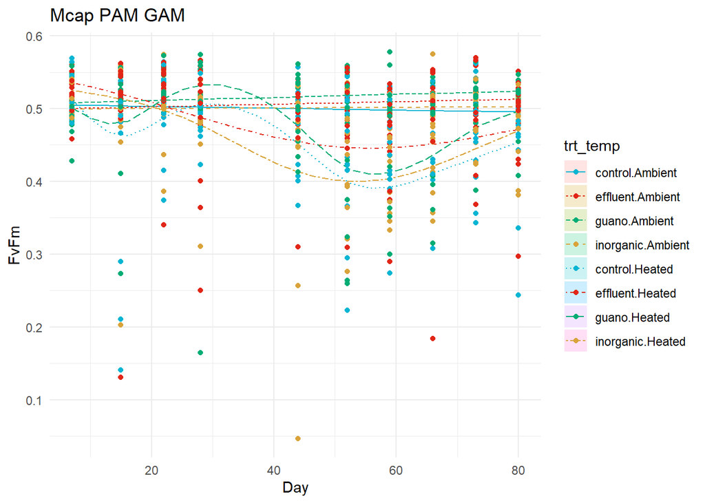

```r
# Plot_smooths for the model output on rawdata - needs a few formatting adjustments
mc_pam_plot<-
  plot_smooths(
  model = mc_pam_1,
series = day,
comparison= trt_temp,
ci_z = 0) +
  geom_point(data=mc_pam,
             aes(x=day, y=FvFm, color=trt_temp)) +
  scale_color_manual(values = c("#08b5d3","#e12618","#01ad74","#d9a33a","#08b5d3","#e12618","#01ad74","#d9a33a")) +
  ggtitle("Mcap PAM GAM") +
  ylab("FvFm") +
  xlab("Day") +
  theme_minimal()
mc_pam_plot
```

## Plot_differences

### Compare each treatment to their heated counterpart

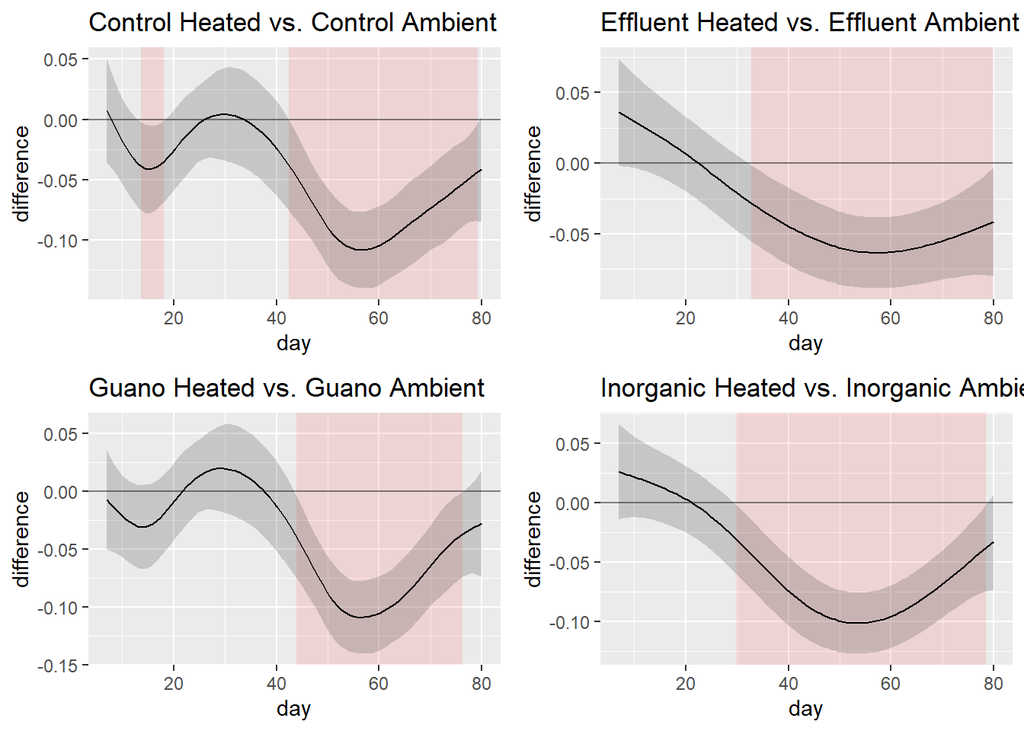

```r
# Define a list of your comparisons
comparisons <- list(
  list(name = "ch_ca", difference = c("control.Heated", "control.Ambient"), title = "Control Heated vs. Control Ambient"),
  list(name = "eh_ea", difference = c("effluent.Heated", "effluent.Ambient"), title = "Effluent Heated vs. Effluent Ambient"),
  list(name = "gh_ga", difference = c("guano.Heated", "guano.Ambient"), title = "Guano Heated vs. Guano Ambient"),
  list(name = "ih_ia", difference = c("inorganic.Heated", "inorganic.Ambient"), title = "Inorganic Heated vs. Inorganic Ambient")
)

# Loop through each comparison to generate plots
plots <- list()  # Initialize an empty list to store plots

for (comp in comparisons) {
  plot <- plot_difference(
    mc_pam_1,
    series = day,
    difference = list(trt_temp = comp$difference)
  ) + ggtitle(comp$title)
    plots[[comp$name]] <- plot
}

# Display plots
grid.arrange(
  plots$ch_ca,
  plots$eh_ea,
  plots$gh_ga,
  plots$ih_ia,
  ncol = 2
)
```

```r
# ambient max 0.578, min 0.131
# heated max 0.574, min 0.047
```

#### Heat was introduced on day 40, inorganic started diverging on day 30, effluent on day 32ish, while control and guano not until a few days into heating. Max FvFm value in dataset was 0.578 and min was 0.047, total range of 0.531. The introduction of heat approximately decreased FvFm values by 20.7% in control corals, 13.2% in effluent corals, 20.7% in guano corals, and 18.8% in inorganic corals. Percentages found by looking at each max difference/0.531. Eg for control 0.11/0.531=0.207

## Difference in all ambient corals to see if treatment had an effect on FvFm

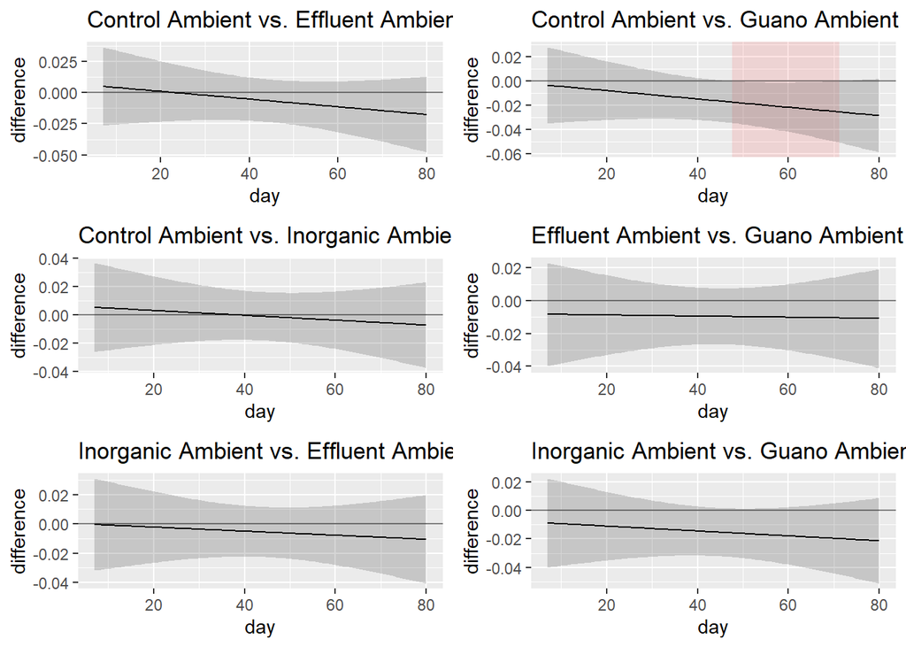

```r
# Define a list of the new comparisons
amb_comparisons <- list(
  list(name = "ca_ea", difference = c("control.Ambient", "effluent.Ambient"), title = "Control Ambient vs. Effluent Ambient"),
  list(name = "ca_ga", difference = c("control.Ambient", "guano.Ambient"), title = "Control Ambient vs. Guano Ambient"),
  list(name = "ca_ia", difference = c("control.Ambient", "inorganic.Ambient"), title = "Control Ambient vs. Inorganic Ambient"),
  list(name = "ea_ga", difference = c("effluent.Ambient", "guano.Ambient"), title = "Effluent Ambient vs. Guano Ambient"),
  list(name = "ia_ea", difference = c("inorganic.Ambient", "effluent.Ambient"), title = "Inorganic Ambient vs. Effluent Ambient"),
  list(name = "ia_ga", difference = c("inorganic.Ambient", "guano.Ambient"), title = "Inorganic Ambient vs. Guano Ambient")
)

# Initialize an empty list to store the new plots
amb_plots <- list()

# Loop through each new comparison to generate plots
for (comp in amb_comparisons) {
  plot <- plot_difference(
    mc_pam_1,
    series = day,
    difference = list(trt_temp = comp$difference)
  ) + ggtitle(comp$title)
    amb_plots[[comp$name]] <- plot
}


# Display plots
grid.arrange(
  amb_plots$ca_ea,
  amb_plots$ca_ga,
  amb_plots$ca_ia,
  amb_plots$ea_ga,
  amb_plots$ia_ea,
  amb_plots$ia_ga,
  ncol = 2
)
```

#### The only difference between the ambient corals was control and guano, guano corals had about 5.6% higher FvFm values compared to control corals between days 47-71. The max value for ambient corals was 0.578 and min was 0.131 with a range of 0.447.

## Difference in all heated corals to see if treatment x heat had an effect on FvFm

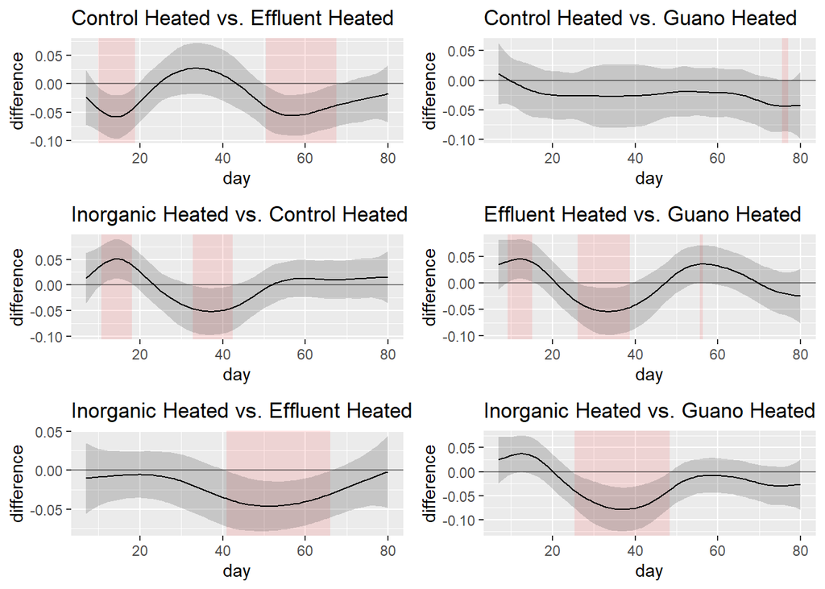

```r
# Define a list of the new comparisons
heat_comparisons <- list(
  list(name = "ch_eh", difference = c("control.Heated", "effluent.Heated"), title = "Control Heated vs. Effluent Heated"),
  list(name = "ch_gh", difference = c("control.Heated", "guano.Heated"), title = "Control Heated vs. Guano Heated"),
  list(name = "ih_ch", difference = c("inorganic.Heated", "control.Heated"), title = "Inorganic Heated vs. Control Heated"),
  list(name = "eh_gh", difference = c("effluent.Heated", "guano.Heated"), title = "Effluent Heated vs. Guano Heated"),
  list(name = "ih_eh", difference = c("inorganic.Heated", "effluent.Heated"), title = "Inorganic Heated vs. Effluent Heated"),
  list(name = "ih_gh", difference = c("inorganic.Heated", "guano.Heated"), title = "Inorganic Heated vs. Guano Heated")
)

# Initialize an empty list to store the new plots
heat_plots <- list()

# Loop through each new comparison to generate plots
for (comp in heat_comparisons) {
  plot <- plot_difference(
    mc_pam_1,
    series = day,
    difference = list(trt_temp = comp$difference)
  ) + ggtitle(comp$title)
    heat_plots[[comp$name]] <- plot
}


# Display plots
grid.arrange(
  heat_plots$ch_eh,
  heat_plots$ch_gh,
  heat_plots$ih_ch,
  heat_plots$eh_gh,
  heat_plots$ih_eh,
  heat_plots$ih_gh,
  ncol = 2
)
```

```r
# heated max 0.574, min 0.047
```

#### The Montipora data is a little squirly, which I think is due to colony 7 (see plot below). Colony 6 is also crazy, however the ambient corals don’t have as much variation as colony 7. I am going to try removing colony 7 to see if the data is easier to interpret.

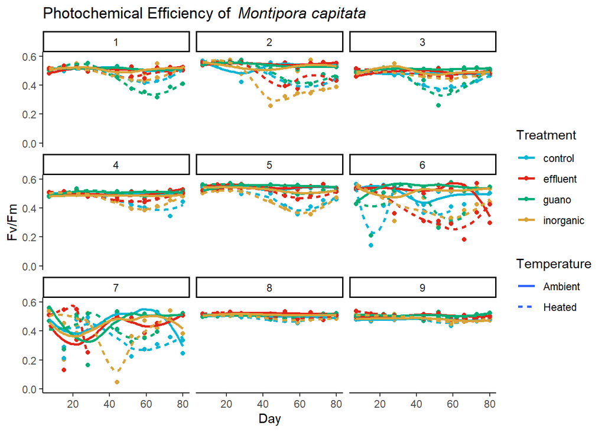

```r
# Plot raw data by colony - regression line is added to see data trends
ggplot(data=mc_pam, aes(x=day, y=FvFm, color=treatment, linetype=temp)) +
  geom_point() +
  facet_wrap(~genotype)+
  geom_smooth(se=F) +
  scale_color_manual(values = c("#08b5d3","#e12618","#01ad74","#d9a33a"))+
  ggtitle(expression(paste("Photochemical Efficiency of", phantom(x), italic("Montipora capitata"))))+
  xlab("Day")+
  ylab("Fv/Fm")+
  labs(color="Treatment",linetype="Temperature")+
  ylim(0, 0.6)+
  theme_classic()
```

```r
# filter data to remove colony 7
mc_pam_filter <- mc_pam %>%
  filter(genotype != 7)
```

```r
# Write different model options
  # Model 1 -different slope and different intercept
  # Model 2 - same slope and different intercept
  # Model 3 - global smoother assuming no treatment differences by day

# Note-allowing 'k' to be set automatically by the model, we can adjust to increase or decrease the 'wiggliness'

mc_pam_4 <- gam(FvFm~ trt_temp + s(day,by=trt_temp),data=mc_pam_filter) #interaction term smoothed by day
summary(mc_pam_4)
```

```
##
## Family: gaussian
## Link function: identity
##
## Formula:
## FvFm ~ trt_temp + s(day, by = trt_temp)
##
## Parametric coefficients:
##                            Estimate Std. Error t value Pr(>|t|)
## (Intercept)                0.505749   0.005085  99.458  < 2e-16 ***
## trt_tempeffluent.Ambient   0.011354   0.007191   1.579 0.114911
## trt_tempguano.Ambient      0.016049   0.007191   2.232 0.026006 *
## trt_tempinorganic.Ambient  0.002169   0.007191   0.302 0.763056
## trt_tempcontrol.Heated    -0.043038   0.007265  -5.924 5.29e-09 ***
## trt_tempeffluent.Heated   -0.025162   0.007292  -3.451 0.000598 ***
## trt_tempguano.Heated      -0.025293   0.007240  -3.494 0.000512 ***
## trt_tempinorganic.Heated  -0.043018   0.007191  -5.982 3.79e-09 ***
## ---
## Signif. codes:  0 '***' 0.001 '**' 0.01 '*' 0.05 '.' 0.1 ' ' 1
##
## Approximate significance of smooth terms:
##                                    edf Ref.df      F p-value
## s(day):trt_tempcontrol.Ambient   1.000  1.000  0.708   0.400
## s(day):trt_tempeffluent.Ambient  1.000  1.000  0.068   0.794
## s(day):trt_tempguano.Ambient     1.000  1.000  0.217   0.641
## s(day):trt_tempinorganic.Ambient 1.000  1.000  0.275   0.600
## s(day):trt_tempcontrol.Heated    5.306  6.419  7.960  <2e-16 ***
## s(day):trt_tempeffluent.Heated   3.015  3.723 11.436  <2e-16 ***
## s(day):trt_tempguano.Heated      5.824  6.973  8.038  <2e-16 ***
## s(day):trt_tempinorganic.Heated  3.459  4.265 16.208  <2e-16 ***
## ---
## Signif. codes:  0 '***' 0.001 '**' 0.01 '*' 0.05 '.' 0.1 ' ' 1
##
## R-sq.(adj) =   0.36   Deviance explained =   39%
## GCV = 0.0021702  Scale est. = 0.0020683  n = 631
```

```r
anova.gam(mc_pam_4)
```

```
##
## Family: gaussian
## Link function: identity
##
## Formula:
## FvFm ~ trt_temp + s(day, by = trt_temp)
##
## Parametric Terms:
##          df    F p-value
## trt_temp  7 21.5  <2e-16
##
## Approximate significance of smooth terms:
##                                    edf Ref.df      F p-value
## s(day):trt_tempcontrol.Ambient   1.000  1.000  0.708   0.400
## s(day):trt_tempeffluent.Ambient  1.000  1.000  0.068   0.794
## s(day):trt_tempguano.Ambient     1.000  1.000  0.217   0.641
## s(day):trt_tempinorganic.Ambient 1.000  1.000  0.275   0.600
## s(day):trt_tempcontrol.Heated    5.306  6.419  7.960  <2e-16
## s(day):trt_tempeffluent.Heated   3.015  3.723 11.436  <2e-16
## s(day):trt_tempguano.Heated      5.824  6.973  8.038  <2e-16
## s(day):trt_tempinorganic.Heated  3.459  4.265 16.208  <2e-16
```

```r
mc_pam_5 <- gam(FvFm~ trt_temp + s(day), data=mc_pam_filter) #interaction term and smoothed day
summary(mc_pam_5)
```

```
##
## Family: gaussian
## Link function: identity
##
## Formula:
## FvFm ~ trt_temp + s(day)
##
## Parametric coefficients:
##                            Estimate Std. Error t value Pr(>|t|)
## (Intercept)                0.505805   0.005485  92.210  < 2e-16 ***
## trt_tempeffluent.Ambient   0.011388   0.007757   1.468  0.14262
## trt_tempguano.Ambient      0.016125   0.007757   2.079  0.03806 *
## trt_tempinorganic.Ambient  0.002188   0.007757   0.282  0.77805
## trt_tempcontrol.Heated    -0.042827   0.007833  -5.467 6.64e-08 ***
## trt_tempeffluent.Heated   -0.024664   0.007861  -3.138  0.00178 **
## trt_tempguano.Heated      -0.025476   0.007808  -3.263  0.00116 **
## trt_tempinorganic.Heated  -0.043250   0.007757  -5.575 3.69e-08 ***
## ---
## Signif. codes:  0 '***' 0.001 '**' 0.01 '*' 0.05 '.' 0.1 ' ' 1
##
## Approximate significance of smooth terms:
##          edf Ref.df     F p-value
## s(day) 4.567  5.582 17.05  <2e-16 ***
## ---
## Signif. codes:  0 '***' 0.001 '**' 0.01 '*' 0.05 '.' 0.1 ' ' 1
##
## R-sq.(adj) =  0.256   Deviance explained = 26.9%
## GCV = 0.002456  Scale est. = 0.0024071  n = 631
```

```r
anova.gam(mc_pam_5)
```

```
##
## Family: gaussian
## Link function: identity
##
## Formula:
## FvFm ~ trt_temp + s(day)
##
## Parametric Terms:
##          df     F p-value
## trt_temp  7 18.49  <2e-16
##
## Approximate significance of smooth terms:
##          edf Ref.df     F p-value
## s(day) 4.567  5.582 17.05  <2e-16
```

```r
mc_pam_6 <- gam(FvFm~ s(day), data=mc_pam_filter) #interaction term and smoothed day
summary(mc_pam_6)
```

```
##
## Family: gaussian
## Link function: identity
##
## Formula:
## FvFm ~ s(day)
##
## Parametric coefficients:
##             Estimate Std. Error t value Pr(>|t|)
## (Intercept) 0.492742   0.002136   230.7   <2e-16 ***
## ---
## Signif. codes:  0 '***' 0.001 '**' 0.01 '*' 0.05 '.' 0.1 ' ' 1
##
## Approximate significance of smooth terms:
##          edf Ref.df     F p-value
## s(day) 4.273  5.236 14.86  <2e-16 ***
## ---
## Signif. codes:  0 '***' 0.001 '**' 0.01 '*' 0.05 '.' 0.1 ' ' 1
##
## R-sq.(adj) =   0.11   Deviance explained = 11.6%
## GCV = 0.0029033  Scale est. = 0.0028791  n = 631
```

```r
anova.gam(mc_pam_6)
```

```
##
## Family: gaussian
## Link function: identity
##
## Formula:
## FvFm ~ s(day)
##
## Approximate significance of smooth terms:
##          edf Ref.df     F p-value
## s(day) 4.273  5.236 14.86  <2e-16
```

```r
# compare models
mc_AIC <- AIC (mc_pam_4, mc_pam_5, mc_pam_6)
print(mc_AIC) # best option is mc_pam_4 (smallest AIC score) with the interaction term smoothed by day
```

```
##                 df       AIC
## mc_pam_4 30.603818 -2078.630
## mc_pam_5 13.567295 -1999.374
## mc_pam_6  6.273238 -1893.583
```

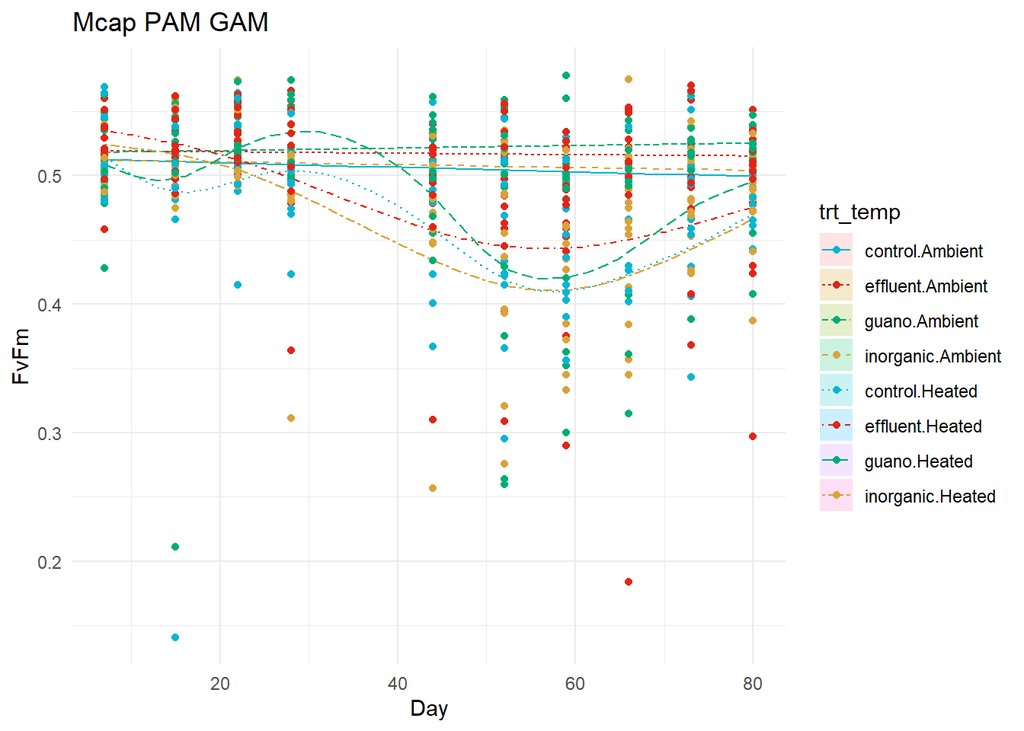

```r
# Plot_smooths for the model output on rawdata - needs a few formatting adjustments
mc_pam_plot_2<-
  plot_smooths(
  model = mc_pam_4,
series = day,
comparison= trt_temp,
ci_z = 0) +
  geom_point(data=mc_pam_filter,
             aes(x=day, y=FvFm, color=trt_temp)) +
  scale_color_manual(values = c("#08b5d3","#e12618","#01ad74","#d9a33a","#08b5d3","#e12618","#01ad74","#d9a33a")) +
  ggtitle("Mcap PAM GAM") +
  ylab("FvFm") +
  xlab("Day") +
  theme_minimal()
mc_pam_plot_2
```

## Plot_differences

### Compare each treatment to their heated counterpart

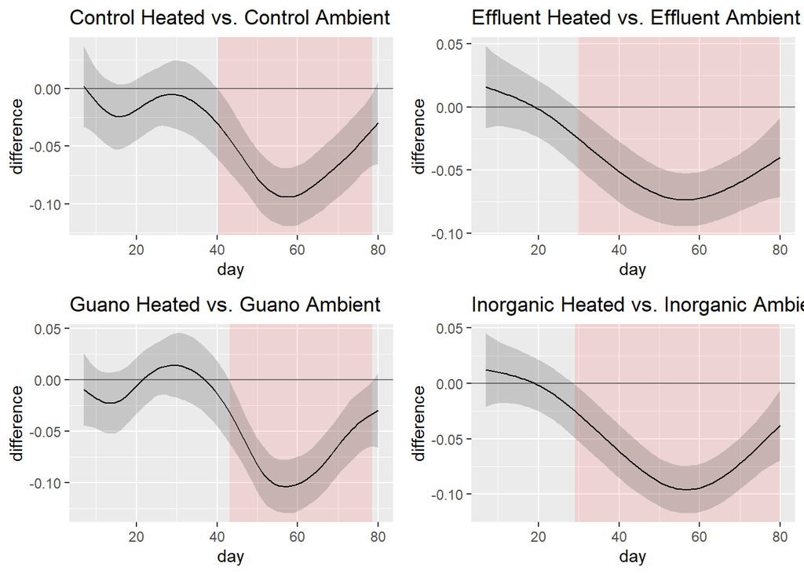

```r
# Define a list of your comparisons
comparisons <- list(
  list(name = "ch_ca", difference = c("control.Heated", "control.Ambient"), title = "Control Heated vs. Control Ambient"),
  list(name = "eh_ea", difference = c("effluent.Heated", "effluent.Ambient"), title = "Effluent Heated vs. Effluent Ambient"),
  list(name = "gh_ga", difference = c("guano.Heated", "guano.Ambient"), title = "Guano Heated vs. Guano Ambient"),
  list(name = "ih_ia", difference = c("inorganic.Heated", "inorganic.Ambient"), title = "Inorganic Heated vs. Inorganic Ambient")
)

# Loop through each comparison to generate plots
plots <- list()  # Initialize an empty list to store plots

for (comp in comparisons) {
  plot <- plot_difference(
    mc_pam_4,
    series = day,
    difference = list(trt_temp = comp$difference)
  ) + ggtitle(comp$title)
    plots[[comp$name]] <- plot
}

# Display plots
grid.arrange(
  plots$ch_ca,
  plots$eh_ea,
  plots$gh_ga,
  plots$ih_ia,
  ncol = 2
)
```

#### Heat was introduced on day 40, inorganic and effluent started diverging on day 30, while control was at day 40 and guano not until a few days into heating. Max FvFm value in dataset was 0.578 and min was 0.141, total range of 0.437. The introduction of heat approximately decreased FvFm values by 20.5% in control corals, 17.2% in effluent corals, 22.9% in guano corals, and 22.9% in inorganic corals. Percentages found by looking at each max difference/0.437. Eg for control 0.09/0.437=0.205

## Difference in all ambient corals to see if treatment had an effect on FvFm

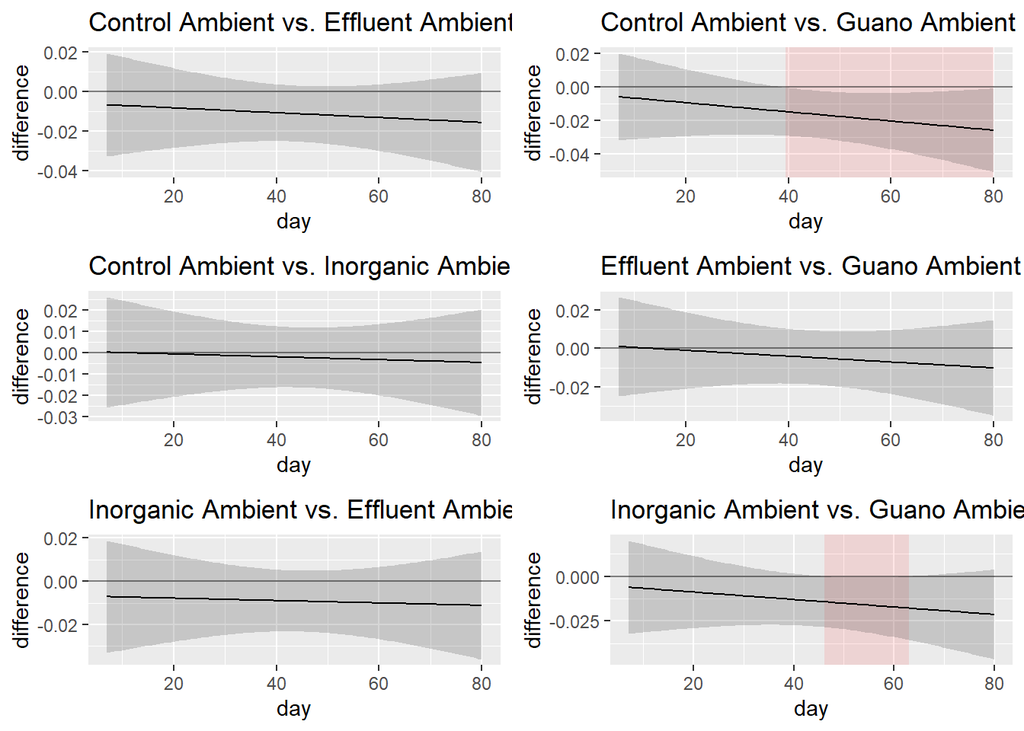

```r
# Define a list of the new comparisons
amb_comparisons <- list(
  list(name = "ca_ea", difference = c("control.Ambient", "effluent.Ambient"), title = "Control Ambient vs. Effluent Ambient"),
  list(name = "ca_ga", difference = c("control.Ambient", "guano.Ambient"), title = "Control Ambient vs. Guano Ambient"),
  list(name = "ca_ia", difference = c("control.Ambient", "inorganic.Ambient"), title = "Control Ambient vs. Inorganic Ambient"),
  list(name = "ea_ga", difference = c("effluent.Ambient", "guano.Ambient"), title = "Effluent Ambient vs. Guano Ambient"),
  list(name = "ia_ea", difference = c("inorganic.Ambient", "effluent.Ambient"), title = "Inorganic Ambient vs. Effluent Ambient"),
  list(name = "ia_ga", difference = c("inorganic.Ambient", "guano.Ambient"), title = "Inorganic Ambient vs. Guano Ambient")
)

# Initialize an empty list to store the new plots
amb_plots <- list()

# Loop through each new comparison to generate plots
for (comp in amb_comparisons) {
  plot <- plot_difference(
    mc_pam_4,
    series = day,
    difference = list(trt_temp = comp$difference)
  ) + ggtitle(comp$title)
    amb_plots[[comp$name]] <- plot
}


# Display plots
grid.arrange(
  amb_plots$ca_ea,
  amb_plots$ca_ga,
  amb_plots$ca_ia,
  amb_plots$ea_ga,
  amb_plots$ia_ea,
  amb_plots$ia_ga,
  ncol = 2
)
```

#### The only difference between the ambient corals was guano vs control and ambient, guano corals had about 9% higher FvFm values compared to control corals between days 40-80 and 5.1% higher FvFm values than inorganic corals days 45-62. The max value for ambient corals was 0.578 and min was 0.297 with a range of 0.281.

## Difference in all heated corals to see if treatment x heat had an effect on FvFm

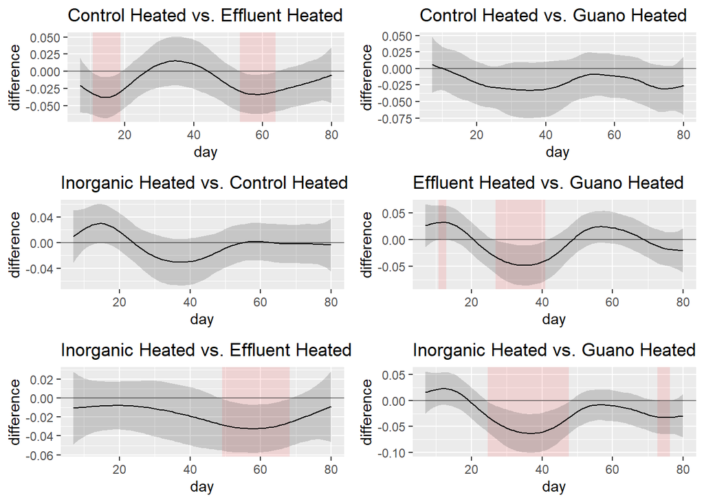

```r
# Define a list of the new comparisons
heat_comparisons <- list(
  list(name = "ch_eh", difference = c("control.Heated", "effluent.Heated"), title = "Control Heated vs. Effluent Heated"),
  list(name = "ch_gh", difference = c("control.Heated", "guano.Heated"), title = "Control Heated vs. Guano Heated"),
  list(name = "ih_ch", difference = c("inorganic.Heated", "control.Heated"), title = "Inorganic Heated vs. Control Heated"),
  list(name = "eh_gh", difference = c("effluent.Heated", "guano.Heated"), title = "Effluent Heated vs. Guano Heated"),
  list(name = "ih_eh", difference = c("inorganic.Heated", "effluent.Heated"), title = "Inorganic Heated vs. Effluent Heated"),
  list(name = "ih_gh", difference = c("inorganic.Heated", "guano.Heated"), title = "Inorganic Heated vs. Guano Heated")
)

# Initialize an empty list to store the new plots
heat_plots <- list()

# Loop through each new comparison to generate plots
for (comp in heat_comparisons) {
  plot <- plot_difference(
    mc_pam_4,
    series = day,
    difference = list(trt_temp = comp$difference)
  ) + ggtitle(comp$title)
    heat_plots[[comp$name]] <- plot
}


# Display plots
grid.arrange(
  heat_plots$ch_eh,
  heat_plots$ch_gh,
  heat_plots$ih_ch,
  heat_plots$eh_gh,
  heat_plots$ih_eh,
  heat_plots$ih_gh,
  ncol = 2
)
```

#### Overall interpreation of Montipora: Heat decreased FvFm in all treatments from about 17.2% in effluent corals to 22.9% in guano and inorganic corals. In ambient corals, guano supported slightly (5-9%) higher FvFm values than inorganic or control corals, respectively. The interaction of heat x treatment caused control corals to be significantly lower (8.7%) than effluent corals, but no different from guano or inorganic corals. Effluent and guano were significantly higher than inorganic corals (6.8% and 16.2%, respectively). Guano corals were 11.5% higher than effluent corals BEFORE heating, but no different during/after heating.

## Linear Mixed Effects Model on just heated corals from day 40 - 80 (start of heating to end of experiment)

```r
# filter dataset
mc_heat <- mc_pam [mc_pam$temp == "Heated",]
mc_heat <- mc_heat %>%
  filter(day >= 40)


#lme
mc_heat_lme <- lmer(FvFm ~ treatment + (1|genotype) + (1|ID), data=mc_heat)
summary(mc_heat_lme)
```

```
## Linear mixed model fit by REML. t-tests use Satterthwaite's method [
## lmerModLmerTest]
## Formula: FvFm ~ treatment + (1 | genotype) + (1 | ID)
##    Data: mc_heat
##
## REML criterion at convergence: -538
##
## Scaled residuals:
##     Min      1Q  Median      3Q     Max
## -5.7413 -0.3748  0.0217  0.4554  3.1931
##
## Random effects:
##  Groups   Name        Variance Std.Dev.
##  ID       (Intercept) 0.000851 0.02917
##  genotype (Intercept) 0.002160 0.04647
##  Residual             0.002636 0.05134
## Number of obs: 198, groups:  ID, 35; genotype, 9
##
## Fixed effects:
##                     Estimate Std. Error        df t value Pr(>|t|)
## (Intercept)         0.419431   0.019690 14.459755  21.301 2.52e-12 ***
## treatmenteffluent   0.026135   0.017891 23.900064   1.461    0.157
## treatmentguano      0.024058   0.017200 23.539242   1.399    0.175
## treatmentinorganic  0.001065   0.017093 23.057388   0.062    0.951
## ---
## Signif. codes:  0 '***' 0.001 '**' 0.01 '*' 0.05 '.' 0.1 ' ' 1
##
## Correlation of Fixed Effects:
##             (Intr) trtmntf trtmntg
## trtmntfflnt -0.420
## treatmentgn -0.436  0.482
## trtmntnrgnc -0.439  0.485   0.502
```

### No treatment differences during heating/recovery phases